# Practcal Machine Learning assignment

Tamás Nagy

# Loading the data

Keeping only the variables that contain momentary data (ie. not the statistics), because we want to be able to give prediction to any given moment. I’ve furthermore omitted the first seven variables to exclude “metadata” and data that might confound the model (e.g. the row number, the name of the participant, etc.)

```r
# Speeding up analysis by using multiple cores
library(doSNOW)
cl <- makeCluster(6, type = "SOCK")
registerDoSNOW(cl)
# stopCluster(cl)
library(caret)
# Reading data
data <- read.csv("pml-training.csv", na.strings = c("#DIV/0!","NA"))
data <- data[,sapply(data, function(x) sum(is.na(x))/length(x) < .95)]
data <- data[,-c(1:7)]

# Data partitioning
set.seed(123)
inTrain <- createDataPartition(y = data$classe, p = .6, list = F)
training <- data[inTrain,]
testing <- data[-inTrain,]
```

# Training

I used two methods (random forest and boosting with trees) to build models, as these methods are among be the bests for classification problems. Simple standardization was used as pre-processing.

Model 1 seems to be more accurate.

```r
# Random forest model
model1 <- train(classe ~ .,data = training,
               preProcess = c("scale","center"),
               method = "rf")
model1
```

```
## Random Forest
##
## 11776 samples
##    52 predictor
##     5 classes: 'A', 'B', 'C', 'D', 'E'
##
## Pre-processing: scaled, centered
## Resampling: Bootstrapped (25 reps)
##
## Summary of sample sizes: 11776, 11776, 11776, 11776, 11776, 11776, ...
##
## Resampling results across tuning parameters:
##
##   mtry  Accuracy   Kappa      Accuracy SD  Kappa SD
##    2    0.9860512  0.9823506  0.001849401  0.002342324
##   27    0.9866895  0.9831605  0.002472923  0.003125156
##   52    0.9782783  0.9725179  0.005060327  0.006405990
##
## Accuracy was used to select the optimal model using  the largest value.
## The final value used for the model was mtry = 27.
```

```r
model1$finalModel
```

```
##
## Call:
##  randomForest(x = x, y = y, mtry = param$mtry)
##                Type of random forest: classification
##                      Number of trees: 500
## No. of variables tried at each split: 27
##
##         OOB estimate of  error rate: 0.87%
## Confusion matrix:
##      A    B    C    D    E class.error
## A 3340    6    0    0    2 0.002389486
## B   17 2253    8    1    0 0.011408513
## C    0   15 2029   10    0 0.012171373
## D    0    2   28 1898    2 0.016580311
## E    0    1    2    8 2154 0.005080831
```

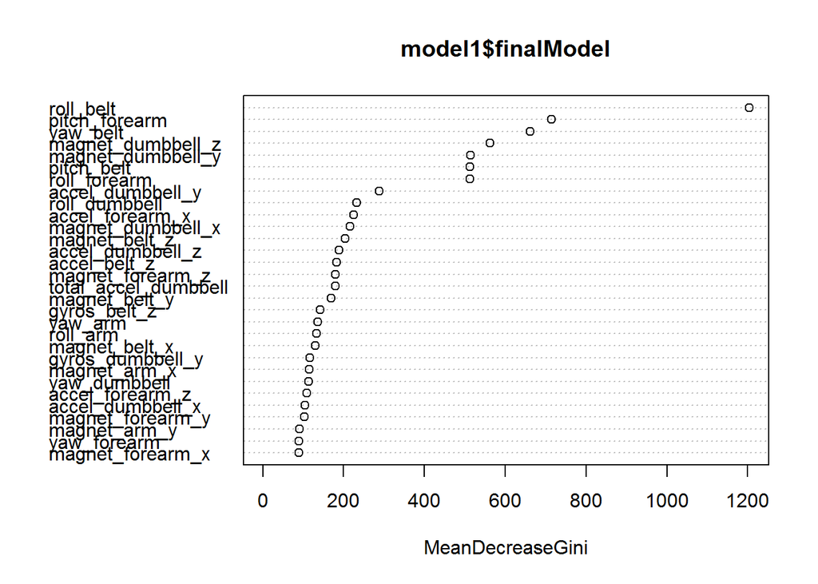

```r
varImpPlot(model1$finalModel)
```

```r
# Tree based bossting model
model2 <- train(classe ~ .,data = training,
               preProcess = c("scale","center"),
               method = "gbm", verbose = F)
model2
```

```
## Stochastic Gradient Boosting
##
## 11776 samples
##    52 predictor
##     5 classes: 'A', 'B', 'C', 'D', 'E'
##
## Pre-processing: scaled, centered
## Resampling: Bootstrapped (25 reps)
##
## Summary of sample sizes: 11776, 11776, 11776, 11776, 11776, 11776, ...
##
## Resampling results across tuning parameters:
##
##   interaction.depth  n.trees  Accuracy   Kappa      Accuracy SD
##   1                   50      0.7502755  0.6834336  0.009802609
##   1                  100      0.8130844  0.7633775  0.008203077
##   1                  150      0.8467597  0.8059970  0.007467044
##   2                   50      0.8463324  0.8052405  0.006693089
##   2                  100      0.8999448  0.8733018  0.005988643
##   2                  150      0.9253166  0.9054472  0.005245786
##   3                   50      0.8904038  0.8611621  0.006519531
##   3                  100      0.9373372  0.9206610  0.005353832
##   3                  150      0.9541929  0.9420146  0.004045306
##   Kappa SD
##   0.012316114
##   0.010256889
##   0.009376625
##   0.008428232
##   0.007553939
##   0.006646900
##   0.008207960
##   0.006793968
##   0.005117200
##
## Tuning parameter 'shrinkage' was held constant at a value of 0.1
## Accuracy was used to select the optimal model using  the largest value.
## The final values used for the model were n.trees = 150,
##  interaction.depth = 3 and shrinkage = 0.1.
```

```r
model2$finalModel
```

```
## A gradient boosted model with multinomial loss function.
## 150 iterations were performed.
## There were 52 predictors of which 44 had non-zero influence.
```

```r
# Prediction using the random forest model
pred <- predict(model1,newdata = testing)
confusionMatrix(pred, testing$classe)
```

```
## Confusion Matrix and Statistics
##
##           Reference
## Prediction    A    B    C    D    E
##          A 2228   15    1    0    0
##          B    4 1500    8    0    0
##          C    0    3 1346   17    5
##          D    0    0   13 1268    5
##          E    0    0    0    1 1432
##
## Overall Statistics
##
##                Accuracy : 0.9908
##                  95% CI : (0.9885, 0.9928)
##     No Information Rate : 0.2845
##     P-Value [Acc > NIR] : < 2.2e-16
##
##                   Kappa : 0.9884
##  Mcnemar's Test P-Value : NA
##
## Statistics by Class:
##
##                      Class: A Class: B Class: C Class: D Class: E
## Sensitivity            0.9982   0.9881   0.9839   0.9860   0.9931
## Specificity            0.9971   0.9981   0.9961   0.9973   0.9998
## Pos Pred Value         0.9929   0.9921   0.9818   0.9860   0.9993
## Neg Pred Value         0.9993   0.9972   0.9966   0.9973   0.9984
## Prevalence             0.2845   0.1935   0.1744   0.1639   0.1838
## Detection Rate         0.2840   0.1912   0.1716   0.1616   0.1825
## Detection Prevalence   0.2860   0.1927   0.1747   0.1639   0.1826
## Balanced Accuracy      0.9977   0.9931   0.9900   0.9916   0.9965
```

```r
# Prediction using the tree based boosting
pred <- predict(model2,testing)
confusionMatrix(pred,testing$classe)
```

```
## Confusion Matrix and Statistics
##
##           Reference
## Prediction    A    B    C    D    E
##          A 2198   42    0    1    4
##          B   22 1432   56    4   13
##          C    8   36 1292   44   14
##          D    4    4   16 1229   27
##          E    0    4    4    8 1384
##
## Overall Statistics
##
##                Accuracy : 0.9604
##                  95% CI : (0.9558, 0.9646)
##     No Information Rate : 0.2845
##     P-Value [Acc > NIR] : < 2.2e-16
##
##                   Kappa : 0.9499
##  Mcnemar's Test P-Value : 8.281e-09
##
## Statistics by Class:
##
##                      Class: A Class: B Class: C Class: D Class: E
## Sensitivity            0.9848   0.9433   0.9444   0.9557   0.9598
## Specificity            0.9916   0.9850   0.9843   0.9922   0.9975
## Pos Pred Value         0.9791   0.9378   0.9268   0.9602   0.9886
## Neg Pred Value         0.9939   0.9864   0.9882   0.9913   0.9910
## Prevalence             0.2845   0.1935   0.1744   0.1639   0.1838
## Detection Rate         0.2801   0.1825   0.1647   0.1566   0.1764
## Detection Prevalence   0.2861   0.1946   0.1777   0.1631   0.1784
## Balanced Accuracy      0.9882   0.9642   0.9643   0.9740   0.9786
```